# EV rebound in an electrifying fleet

A diffusion model with heterogeneous ICEV disutility, calibrated to the Dutch BEV fleet

Working draft, 27 October 2026

**Status.** This is a working model. The rebound target (10 log points for the 2015 cohort) is a **fictitious placeholder**, to be replaced by register-data estimates per cohort. The levels are illustrative.

# 1 Question

How does the driving rebound of households that switch from an ICEV to a BEV develop over time as the fleet electrifies?

# 2 Model

## 2.1 Driving

The model makes one behavioural assumption about heterogeneity: **households differ in their disutility from driving an ICEV**, for example because of climate concerns. Who switches when, and each cohort’s rebound, follow from optimising behaviour and the observed diffusion of BEVs.

A household $i$ owns one car. The perceived cost per km is

$$c^I_i = p_f + \psi_i \quad\text{(ICEV)}, \qquad c^E \quad\text{(EV)},$$

where $\psi_i \ge 0$ is the household’s disutility per km driven with an ICEV. This is the heterogeneous primitive. Demand for km has a common elasticity, $v_i(c) = k_i (c/c^I_i)^{-\varepsilon}$, where $k_i$ is the household’s km with the ICEV.

The rebound is the log change in km on switching:

$$r_i = \varepsilon \ln\frac{c^I_i}{c^E}.$$

## 2.2 Adoption

The gain from switching is the present value of the extra surplus from driving, plus a lump-sum taste term $g_i \sim N(0,\sigma_g^2)$ (warm glow, fit of available models). The taste term does not affect driving:

$$G_i = A \int_{c^E}^{c^I_i} v_i(c)\,dc + g_i
=
A\,\frac{k_i\,c^I_i}{1-\varepsilon}\left[1-\left(\frac{c^E}{c^I_i}\right)^{1-\varepsilon}\right]
+ g_i .$$

Here $A$ is an annuity factor over $8$ years at $4\%$.

A household can only switch when it replaces its car, which it does with probability $\lambda = 0.12$ per year. It then switches if $G_i \ge F_t$, where $F_t$ is the net EV premium in year $t$.

## 2.3 What the model implies for rebound over time

Both the gain and the rebound rise in $\psi_i$:

$$\frac{\partial G_i}{\partial \psi_i} = A\,v_i(c^I_i) > 0, \qquad
\frac{\partial r_i}{\partial \psi_i} = \frac{\varepsilon}{c^I_i} > 0
.$$

Households with a high ICEV disutility therefore switch earlier *and* rebound more. As $F_t$ falls, adoption moves to households with a lower $\psi$, and the cohort rebound declines.

How strong this is depends on how much of the variation in $G$ comes from $\psi$ rather than from $k$ and $g$. Those two shift adoption but not the rebound. With a homogeneous $\psi$, or with adoption timing unrelated to type, rebound is the same for every cohort.

## 2.4 Assumptions

| Parameter | Value | Basis |
| --- | --- | --- |
| fuel cost $p_f$ | €0.12/km | 6.5 l/100 km at €1.85/l |
| EV cost $c^E$ | €0.06/km | mix of home and public charging, about €0.35/kWh |
| ICEV disutility $\psi$ | lognormal, mean €0.02/km, sdlog 1.5 | ≈ €130/tCO₂ at 0.15 kg/km |
| km $k$ | lognormal, mean 13,000, sdlog 0.55 | CBS: about 12,300 km |
| elasticity $\varepsilon$ | common, **calibrated** |  |
| taste sd $\sigma_g$ | **calibrated** |  |
| replacement rate $\lambda$ | 0.12 |  |

All type components are drawn independently.

# 3 Calibration

| Target | Source | Pins down |
| --- | --- | --- |
| BEV share of cars in use, 2015–2026 | StatLine 83703NED, 85405NED; 2025–2026 extended with new BEV sales (85898NED) | $F_t$, exactly |
| rebound of the 2015 cohort (all adopters up to 2015) = 10 log points | **placeholder** | $\varepsilon$ = 0.040 |
| km of BEVs / all cars in use, 2024 = 1.47 | StatLine 85405NED | $\sigma_g$ = €11,741 |

The BEV share uses the ‘full elektrisch’ category. The fuel type ‘Elektriciteit’ in the fleet tables includes hybrids.

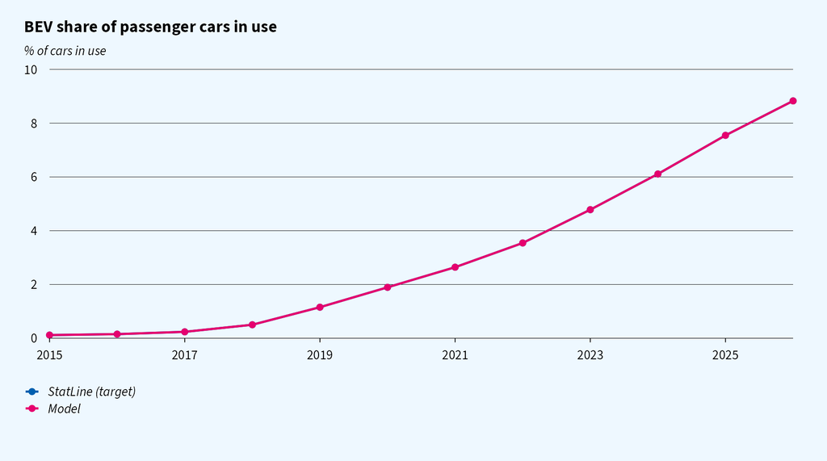

# 4 Results

## 4.1 Rebound over time

With a heterogeneous ICEV disutility, the cohort rebound falls from 10.0 log points (adopters up to 2015) to 3.5 (2026). Most of the decline happens before the BEV share reaches about 1% (2019). After that, the profile is nearly flat.

With a homogeneous disutility, or with random timing, the rebound is constant. Each scenario is recalibrated to the same 2015 target.

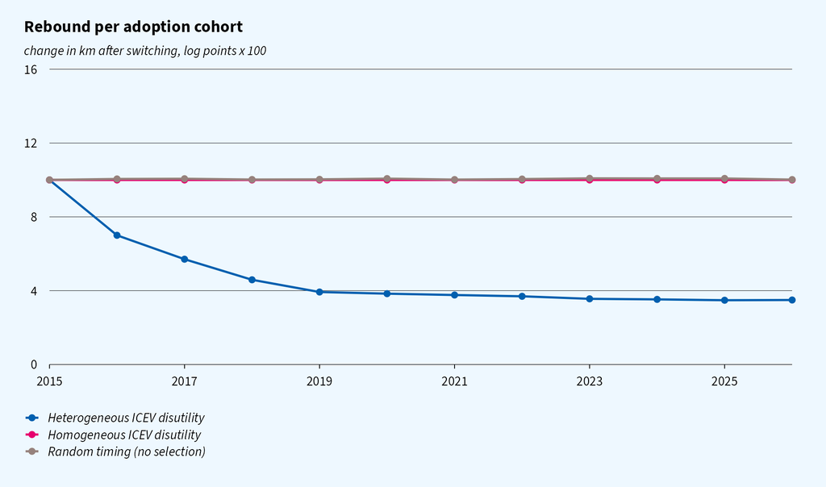

## 4.2 Who switches

Early cohorts have a high ICEV disutility and drive a lot. Both fall as the fleet electrifies.

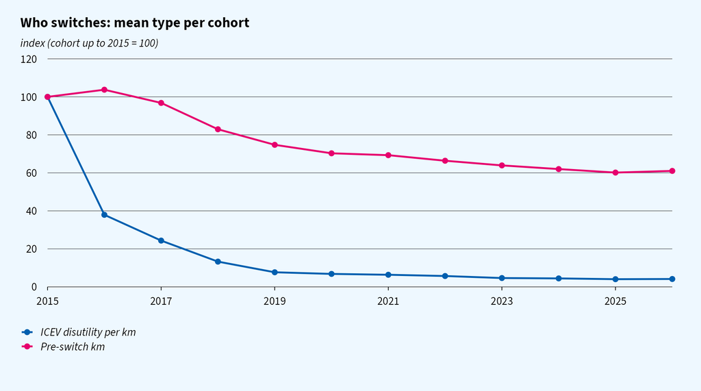

The figure below shows the rebound each household would have if it switched, ordered by its gain. The remaining ICEV owners would rebound somewhat less than the first adopters, but the curve is flat over most of the population.

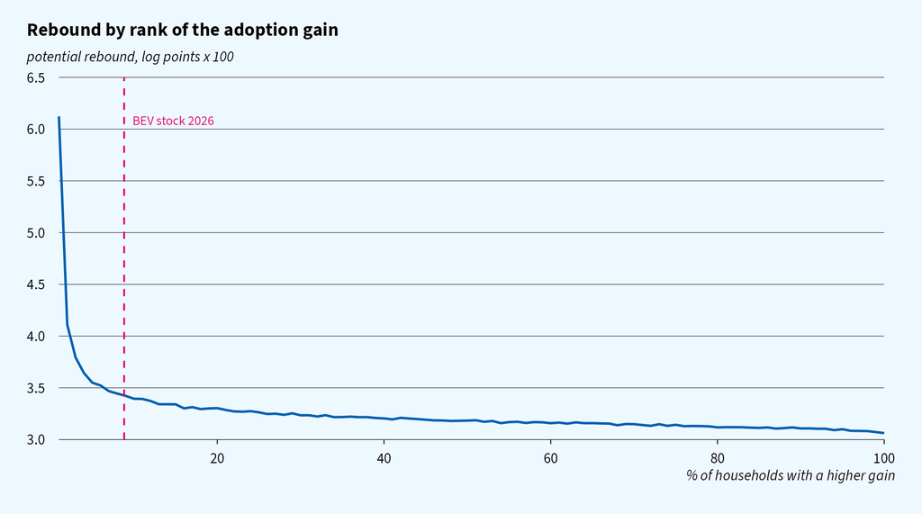

## 4.3 Untargeted check: km of BEVs over time

The model matches the 2024 ratio. In earlier years, it has BEVs driven far more than the average car, while StatLine shows a modest ratio that rises over time. This points to constraints the model leaves out:

- the limited range of early BEVs;
- company cars.

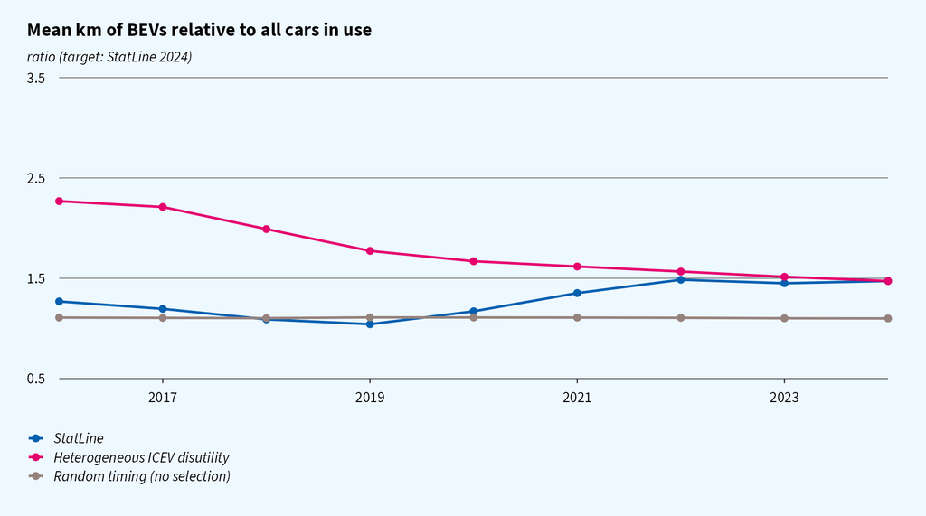

# 5 Next steps

1. Target the full **rebound profile per cohort** from register data. Whether, and how steeply, it declines identifies how dispersed the ICEV disutility is.
2. Add a **range constraint** that loosens over time, and a **company car segment**.
3. Separate **cohort, period and duration effects**, using ICEV-to-ICEV replacers as controls.
4. Compute the **rebound of the remaining ICEV owners** under a phase-out.

Code: [`R/`](https://github.com/joris-klingen/ev_reb_model/tree/main/R). Specification: [`docs/model.md`](https://github.com/joris-klingen/ev_reb_model/blob/main/docs/model.md). Figures: ggcpb, open source fallback font.